# Exercice 1

## Question 1

```python
x, y = var('x, y')
f = 3 / 4 + (x^2 + 4 * x * y + y^2) / 2 + x^2 * y^2
plot3d(f, (x, -1, 1), (y, -1, 1))
```

[interactive chart not shown]

## Question 2

```python
g = x^2 * (1 + y^2) + y^2
plot3d(g, (x, -1, 1), (y, -2, 2))
```

[interactive chart not shown]

# Question 3

```python
plot3d(f, (x, -0.5, 0.5), (y, -0.5, 0.5))
```

[interactive chart not shown]

```python
plot3d(g, (x, -0.5, 0.5), (y, -0.5, 0.5))
```

[interactive chart not shown]

# Exercice 2

## Question 1

```python
f = x^3 - 4 * x * y^2
plot3d(f, (x, -2, 2), (y, -2, 2))
```

[interactive chart not shown]

## Question 2

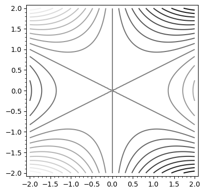

```python
contour_plot(f, (x, -2, 2), (y, -2, 2), fill=False, contours=20)
```

## Question 3

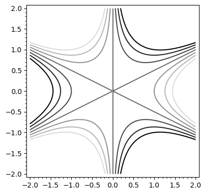

```python
contour_plot(f, (x, -2, 2), (y, -2, 2), fill=False, contours=[-3..3])
```

# Exercice 3

## Question 1

```python
f = x^3 - 4 * x * y^2
V = VectorSpace(RR, 2)  # On introduit l’espace vectoriel R^2 pour pouvoir manipuler des vecteurs et non des uplets.

grad = f.gradient()(x=1, y=1)
u = V((1, 1)) + V(grad) / 8
u
```

```
(0.875000000000000, 0.000000000000000)
```

## Question 2

```python
grad = f.gradient()(x=1, y=0)
v = V((1, 0)) + V(grad) / 3
v
```

```
(2.00000000000000, 0.000000000000000)
```

```python
grad = f.gradient()(x=-1, y=1)
w = V((-1, 1)) + V(grad) / 8
w
```

```
(-1.12500000000000, 2.00000000000000)
```

## Question 3

On affiche le niveau des courbes et les points étudiés pour mieux voir.

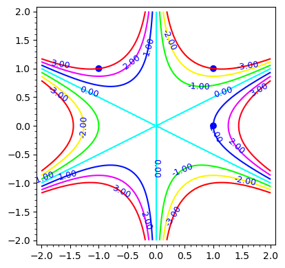

```python
P = point([(1, 1), (1, 0), (-1, 1)], size=50)
P + contour_plot(f, (x, -2, 2), (y, -2, 2),
                 fill=False,
                 contours=[-3..3],
                 labels=True,
                 cmap='hsv')
```

Les points $(1, 1)$, $(1, 0)$ et $(-1, 1)$ se trouvent respectivement sur les lignes de niveaux $-3$, $1$ et $3$ de la fonction $f$.

## Question 4

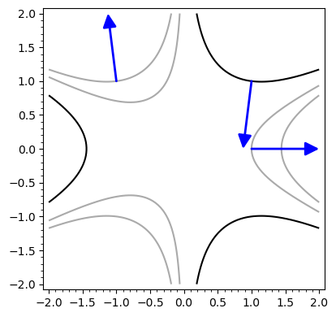

```python
P = contour_plot(f, (x, -2, 2), (y, -2, 2),
                 fill=False,
                 contours=[-3, 1, 3])
P + arrow((1, 1), u) + arrow((1, 0), v) + arrow((-1, 1), w)
```

On remarque que les trois vecteurs tracés sont orthogonaux aux courbes de niveaux.

# Exercice 4

## Question 1

```python
f = x^2 - x^3 + y^2
P = plot3d(f, (x, -2, 2), (y, -2, 2), aspect_ratio=[4, 4, 1])
P + point((0, 0, f(x=0, y=0)), size=100, color='red')
```

[interactive chart not shown]

## Question 2

```python
f.hessian()(x=0, y=0)
```

```
[2 0]
[0 2]
```

La hessienne de la fonction $f$ à l’origine étant définie positive, l’origine est un minimum local.

## Question 3

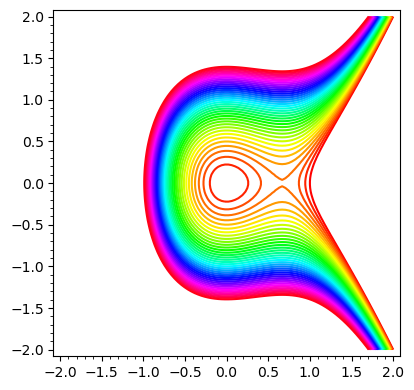

```python
import pylab as plt


contour_plot(f, (x, -2, 2), (y, -2, 2),
             fill=False,
             contours=plt.arange(0, 2, 0.05),
             cmap='hsv')
```

## Question 4

```python
grad = f.gradient()
grad
```

```
(-3*x^2 + 2*x, 2*y)
```

```python
solve(list(grad), [x, y])
```

```
[[x == 0, y == 0], [x == (2/3), y == 0]]
```

On conjecture alors deux points critiques, à savoir l’origine et le point $(2/3, 0)$. C’est bien cohérent avec le graphique.

```python
f = x^2 - x^3 + y^2
P + point((0, 0, f(x=0, y=0)), size=100, color='red') \
  + point((2 / 3, 0, f(x=2 / 3, y=0)), size=100, color='red')
```

[interactive chart not shown]

# Exercice 5

## Question 1

```python
x, y = var('x, y')
f = x^2 + 2 * y^2 - 2 * x * y - x
grad = f.gradient()
grad
```

```
(2*x - 2*y - 1, -2*x + 4*y)
```

```python
solve(list(grad), [x, y])
```

```
[[x == 1, y == (1/2)]]
```

## Question 2

Si la fonction $f$ admet un minimum, alors c’est nécessairement un point critique. On se concentre donc sur une région autour du point $(1, 1/2)$.

```python
P = plot3d(f, (x, 0, 1.5), (y, 0, 1))
P + point((1, 0.5, f(x=1, y=0.5)), size=10, color='red')
```

[interactive chart not shown]

## Question 3

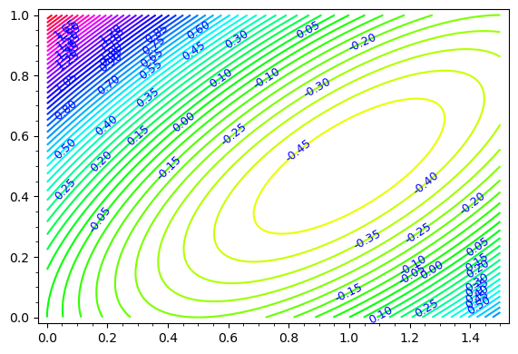

```python
contour_plot(f, (x, 0, 1.5), (y, 0, 1),
                 fill=False,
                 contours=plt.arange(-1, 2, 0.05),
                 labels=True,
                 cmap='hsv')
```

On conjecture que la valeur du minimum vaut $-1/2$.

## Question 4

```python
(x0, y0) = (1, 1)
epsilon = 0.01
rho = 0.01

while norm(grad(x=x0, y=y0)) > epsilon:
    x0 -= rho * grad(x=x0, y=y0)[0]
    y0 -= rho * grad(x=x0, y=y0)[1]

(x0, y0)
```

```
(1.01106827122234, 0.506802353748180)
```

Le signe $-$ devant le réel positif $\rho$ s’explique de la manière suivante. En un point donné, le gradient de la fonction $f$ donne la direction vers laquelle la fonction $f$ croît le plus. Comme on veut chercher un minimum, on doit donc aller dans la direction opposée au gradient.

# Exercice 6

On prend bien soin de remplacer `pi` par une de ses valeurs numériques approchées pour éviter des problèmes lors des comparaisons de valeurs numériques et d’expression dépendant du symbole `pi`.

```python
pi = RR.pi()
f = sin(pi * (x^2 + y^2)) / (1 + x^2)
grad = f.gradient()
grad
```

```
(6.28318530717959*x*cos(3.14159265358979*x^2 + 3.14159265358979*y^2)/(x^2 + 1) - 2*x*sin(3.14159265358979*x^2 + 3.14159265358979*y^2)/(x^2 + 1)^2, 6.28318530717959*y*cos(3.14159265358979*x^2 + 3.14159265358979*y^2)/(x^2 + 1))
```

```python
plot3d(f, (x, -2, 2), (y, -2, 2))
```

[interactive chart not shown]

La fonction possède beaucoup d’oscillations. Il va falloir bien choisir le point initial dans la méthode du gradient pour approcher un minimum. Par exemple, on voit que l’origine est un minimum : on va donc choisir un point initial tout proche de l’origine.

```python
solve(list(grad), [x, y])
```

[output not shown]

Sage ne sait pas résoudre l’équation symboliquement $\nabla f(x, y) = 0$.

```python
(x0, y0) = (0.4, 0.4)
epsilon = 0.01
rho = 0.01

while norm(grad(x=x0, y=y0)) > epsilon:
    x0 -= rho * grad(x=x0, y=y0)[0]
    y0 -= rho * grad(x=x0, y=y0)[1]

(x0, y0)
```

```
(0.00119884564364016, 0.000959074263193407)
```

La méthode nous renvoie bien un point proche de l'origine.